# R Notebook

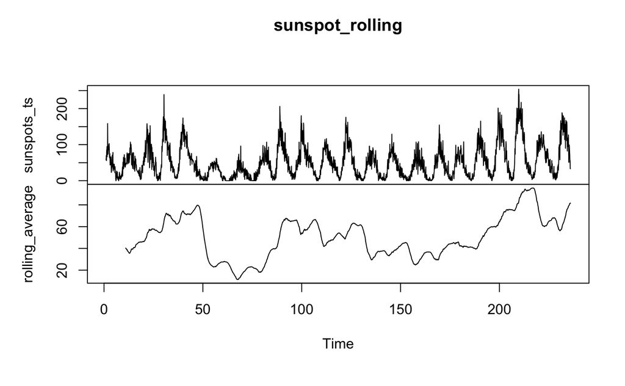

```r
sunspot_rolling <- cbind(sunspots_ts, rolling_average)
plot(sunspot_rolling)
```

4. Decompose the time series and look at the different components. Make sure you use the right type of decomposition. Then take a look at your different components. What does it all tell you? Hint: you might need to subset some of your data in order to see patterns more clearly

```r
# decompose the data
sunspots_tsc$seasonal
```

```
            Jan        Feb        Mar        Apr        May        Jun        Jul
1749 -2.1619020 -0.1085010 -1.2754348 -0.2400181  1.1422112  0.2472504  0.1120830
1750 -2.1619020 -0.1085010 -1.2754348 -0.2400181  1.1422112  0.2472504  0.1120830
1751 -2.1619020 -0.1085010 -1.2754348 -0.2400181  1.1422112  0.2472504  0.1120830
1752 -2.1619020 -0.1085010 -1.2754348 -0.2400181  1.1422112  0.2472504  0.1120830
1753 -2.1619020 -0.1085010 -1.2754348 -0.2400181  1.1422112  0.2472504  0.1120830
1754 -2.1619020 -0.1085010 -1.2754348 -0.2400181  1.1422112  0.2472504  0.1120830
1755 -2.1619020 -0.1085010 -1.2754348 -0.2400181  1.1422112  0.2472504  0.1120830
1756 -2.1619020 -0.1085010 -1.2754348 -0.2400181  1.1422112  0.2472504  0.1120830
1757 -2.1619020 -0.1085010 -1.2754348 -0.2400181  1.1422112  0.2472504  0.1120830
1758 -2.1619020 -0.1085010 -1.2754348 -0.2400181  1.1422112  0.2472504  0.1120830
1759 -2.1619020 -0.1085010 -1.2754348 -0.2400181  1.1422112  0.2472504  0.1120830
1760 -2.1619020 -0.1085010 -1.2754348 -0.2400181  1.1422112  0.2472504  0.1120830
1761 -2.1619020 -0.1085010 -1.2754348 -0.2400181  1.1422112  0.2472504  0.1120830
1762 -2.1619020 -0.1085010 -1.2754348 -0.2400181  1.1422112  0.2472504  0.1120830
```

[output cut: 154 more lines]

```r
# decompose the data
sunspots_tsc$trend
```

```
              Jan          Feb          Mar          Apr          May          Jun
1749           NA           NA           NA           NA           NA           NA
1750  89.02500000  90.16250000  92.32916667  92.55833333  88.17916667  83.80000000
1751  66.75416667  64.15833333  59.53750000  54.94583333  51.72500000  48.96666667
1752  47.16250000  46.39583333  45.27500000  46.40000000  47.75416667  47.96666667
1753  38.19166667  36.25416667  36.69583333  35.83333333  34.20000000  32.07916667
1754  17.08333333  15.82916667  13.89166667  13.02916667  12.70833333  12.32083333
1755   9.20000000   8.39583333   8.41666667   8.80000000   8.51666667   8.90833333
1756  11.45000000  11.37500000  11.25833333  10.61666667  10.65000000  10.63333333
1757  17.96666667  20.72916667  23.76250000  25.68333333  28.42916667  31.42083333
1758  46.54166667  46.80833333  47.23333333  48.40000000  47.71250000  47.20416667
1759  46.45833333  48.10833333  50.07916667  51.60833333  52.66250000  53.38333333
1760  62.50833333  63.31250000  62.82916667  61.78750000  61.96666667  62.69166667
1761  75.67916667  77.49583333  79.78333333  83.01250000  85.85000000  86.47500000
1762  68.30416667  64.81666667  62.50000000  60.35000000  59.04583333  59.85000000
```

[output cut: 154 more lines]

```r
# decompose the data
sunspots_tsc$random
```

```
               Jan           Feb           Mar           Apr           May
1749            NA            NA            NA            NA            NA
1750 -13.563097994 -14.153998991  -1.853731897  -4.018315230   0.678622092
1751   5.407735340 -20.549832324 -12.962065230   1.694184770   7.832788758
1752 -10.000597994   3.712667676  27.000434770  13.140018103  10.803622092
1753   7.970235340  -4.145665658  10.279601436   2.406684770   0.657788758
1754 -14.921431327 -12.720665658 -10.916231897   0.910851436   6.849455425
1755   3.161902006   2.912667676  -0.341231897  -2.059981897  -9.658877908
1756   3.211902006  -4.166498991  -4.582898564  -0.976648564   0.707788758
1757  -1.704764660   0.579334342   3.712934770   4.556684770   8.528622092
1758  -6.779764660   5.300167676   3.042101436  24.140018103  -2.454711242
1759   4.003568673  -3.999832324  -2.003731897  -4.368315230  -4.804711242
1760   6.953568673  -3.703998991  13.146268103  -3.247481897   8.891122092
1761  -3.517264660  13.612667676   2.192101436 -11.072481897  20.207788758
1762 -22.342264660   8.091834342 -15.524565230   0.090018103 -20.288044575
```

[output cut: 238 more lines]

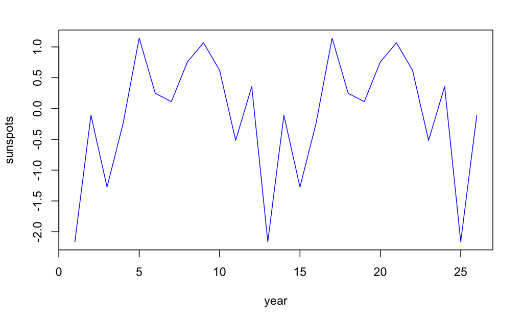

```r
plot(sunspots_tsc$seasonal[1:26], x = 1:26, type = "l", col = "blue", xlab = "year", ylab = "sunspots")
```

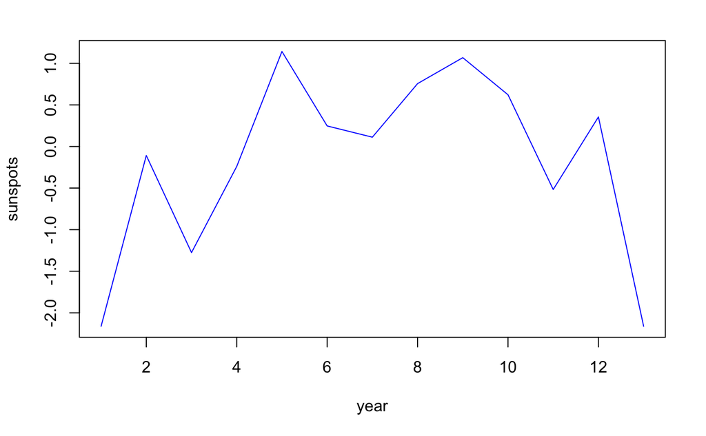

```r
plot(sunspots_tsc$seasonal[1:13], x = 1:13, type = "l", col = "blue", xlab = "year", ylab = "sunspots")
```

5. Check if your data is stationary using the appropriate plots. Do you have stationary data? If no, make the data stationary.

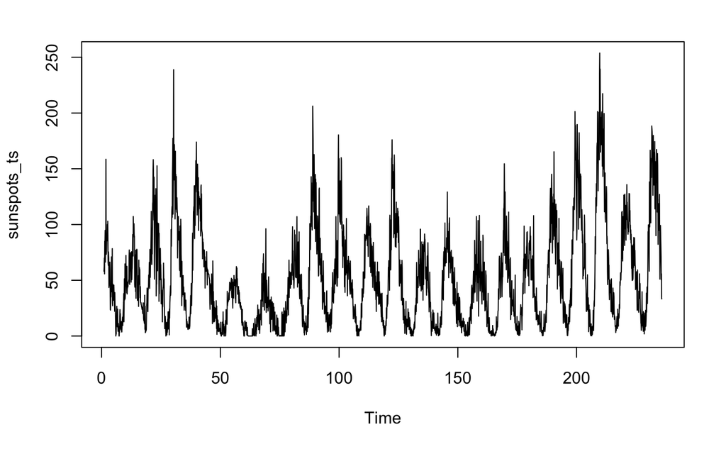

```r
plot(sunspots_ts)
```

```r
cycle(sunspots)
```

```
     Jan Feb Mar Apr May Jun Jul Aug Sep Oct Nov Dec
1749   1   2   3   4   5   6   7   8   9  10  11  12
1750   1   2   3   4   5   6   7   8   9  10  11  12
1751   1   2   3   4   5   6   7   8   9  10  11  12
1752   1   2   3   4   5   6   7   8   9  10  11  12
1753   1   2   3   4   5   6   7   8   9  10  11  12
1754   1   2   3   4   5   6   7   8   9  10  11  12
1755   1   2   3   4   5   6   7   8   9  10  11  12
1756   1   2   3   4   5   6   7   8   9  10  11  12
1757   1   2   3   4   5   6   7   8   9  10  11  12
1758   1   2   3   4   5   6   7   8   9  10  11  12
1759   1   2   3   4   5   6   7   8   9  10  11  12
1760   1   2   3   4   5   6   7   8   9  10  11  12
1761   1   2   3   4   5   6   7   8   9  10  11  12
1762   1   2   3   4   5   6   7   8   9  10  11  12
```

[output cut: 70 more lines]

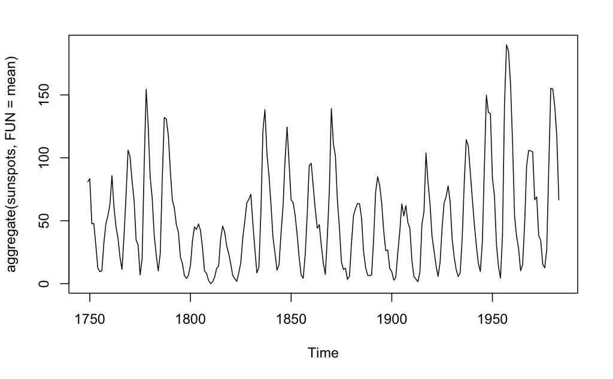

```r
plot(aggregate(sunspots, FUN = mean))
```

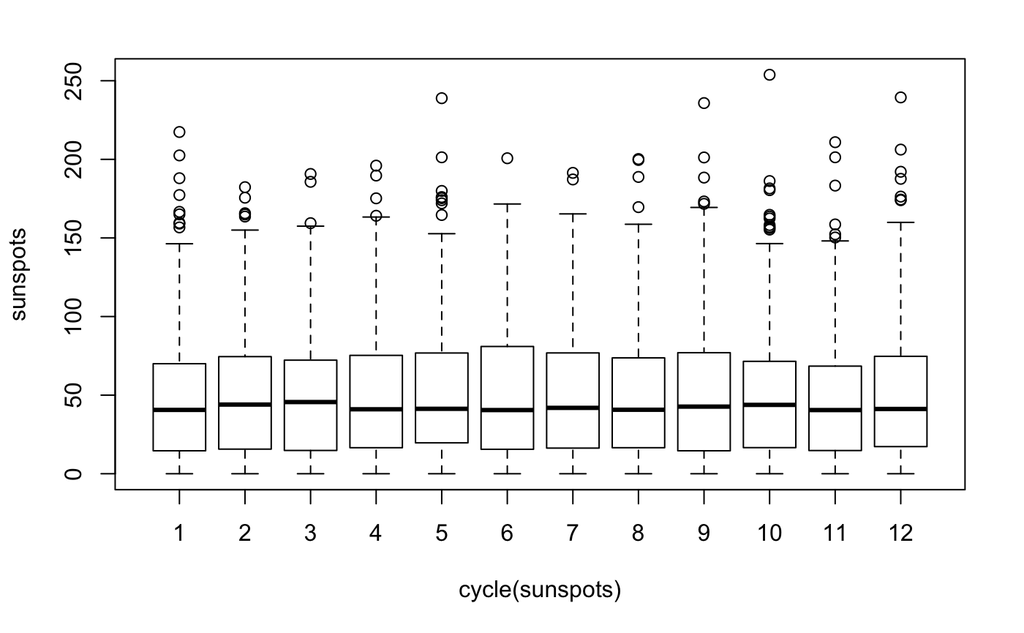

```r
boxplot(sunspots~cycle(sunspots))
```

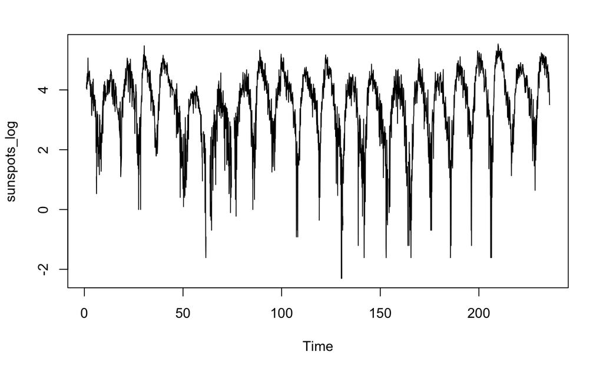

```r
sunspots_log <- log(sunspots_ts)
plot(sunspots_log)
```

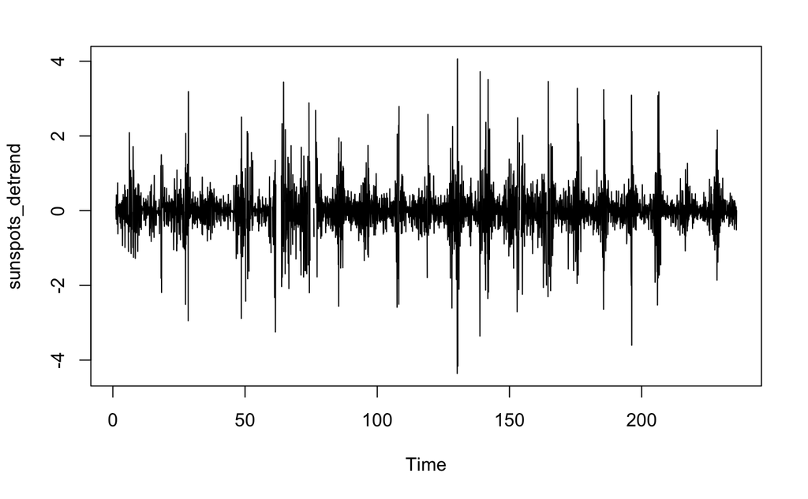

```r
sunspots_detrend <- diff(sunspots_log)
plot(sunspots_detrend)
```

```r
# now stationary?
library(tseries)
# do the augmented dickey-fuller test
adf.test(sunspots, alternative = "stationary", k = 0)
```

```
p-value smaller than printed p-value
```

```
    Augmented Dickey-Fuller Test

data:  sunspots
Dickey-Fuller = -10.843, Lag order = 0, p-value = 0.01
alternative hypothesis: stationary
```

6. Now we have our data, choose your ARIMA model parameters. Create ACF and PACF plots to check, and write a summary of what you have found.

```r
arimaAP <- auto.arima(sunspots, approximation = FALSE)
arimaAP
```

```
Series: sunspots
ARIMA(2,1,2)

Coefficients:
         ar1      ar2      ma1     ma2
      1.3467  -0.3963  -1.7710  0.8103
s.e.  0.0303   0.0287   0.0205  0.0194

sigma^2 estimated as 243.8:  log likelihood=-11745.5
AIC=23500.99   AICc=23501.01   BIC=23530.71
```

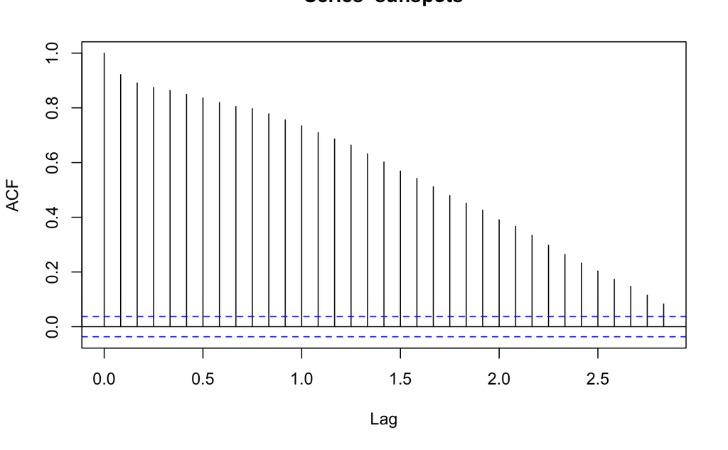

```r
# p, d, q

# p = 2 (auto regression)
# d = 1 (differencing parameter)
# q = 2 (moving avg)

#ACF plot
acf(sunspots)
```

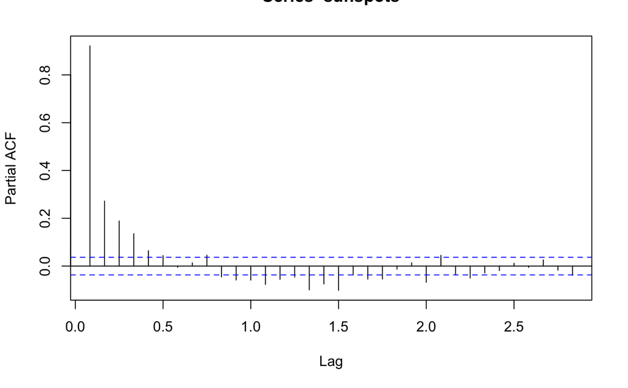

```r
#PACF plot
pacf(sunspots)
```

7. Fit an ARIMA model that predicts the sunspots for the next 20 years. Plot the data, and have a look at your forecast. Does it look like a good forecast or good fit?

```r
# fit using the model parameters calculated from before
fit <- arima(sunspots, c(2, 1, 2))
fit
```

```
Call:
arima(x = sunspots, order = c(2, 1, 2))

Coefficients:
         ar1      ar2      ma1     ma2
      1.3467  -0.3963  -1.7710  0.8103
s.e.  0.0303   0.0287   0.0205  0.0194

sigma^2 estimated as 243.5:  log likelihood = -11745.5,  aic = 23500.99
```

```
    Ljung-Box test

data:  Residuals from ARIMA(2,1,2)
Q* = 50.187, df = 20, p-value = 0.0002082

Model df: 4.   Total lags used: 24
```

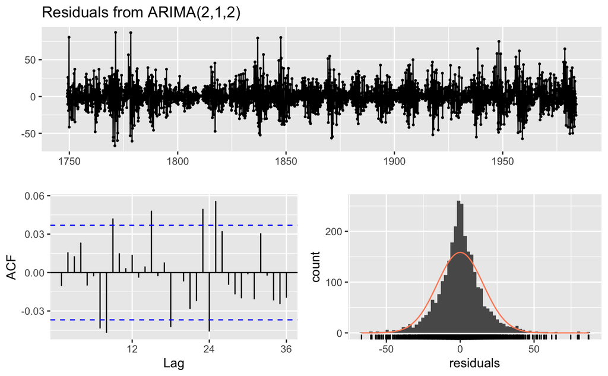

```r
# check the residuals
checkresiduals(fit)
```

```
67 y values <= 0 omitted from logarithmic plot
```

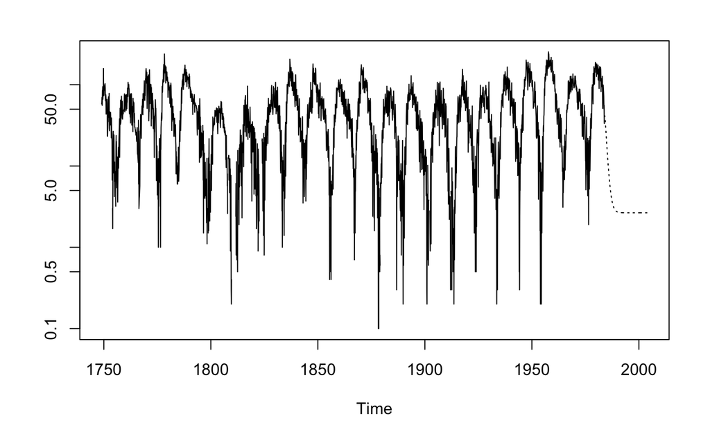

```r
# use the predict function to predict 20 years ahead (20 * 12 months)
pred <- predict(fit, n.ahead = 20*12)

# plot the sunspot data, along with the redicted data
ts.plot(sunspots, pred$pred, log = "y", lty = c(1,3))
```

8. Problem solving: Your model isn’t predicting that well. What are some reasons you can think for this?

```r
# I've made a mistake somewhere in the process?
```

9. Problem solving:

In the present case, sunspots have a cycle of length 11 years. To know this, you’d have to know something about sunspots. You can find this here. The sunspots data are a monthly time series. Thus, the implicit seasonality of sunspots is 12 (months), not 11×12=132 (months).

ARIMA and auto.arima() were never built to automatically detect a seasonal cycle whose length is not pre-specified. It is not overly surprising it does not see that it should do 11 seasonal differences to model a seasonality that repeats every 11 cycles of its prespecified frequency.

```r
arimaAP <- auto.arima(sunspots, approximation = FALSE)
arimaAP
```

```
Series: sunspots
ARIMA(2,1,2)

Coefficients:
         ar1      ar2      ma1     ma2
      1.3467  -0.3963  -1.7710  0.8103
s.e.  0.0303   0.0287   0.0205  0.0194

sigma^2 estimated as 243.8:  log likelihood=-11745.5
AIC=23500.99   AICc=23501.01   BIC=23530.71
```

```r
myts <- ts(sunspots, start=c(start(sunspots), 1), end=c(end(sunspots), 1112), frequency= frequency(sunspots))
auto.arima(myts, seasonal = T)
```

```
Series: myts
ARIMA(2,1,2)

Coefficients:
         ar1      ar2      ma1     ma2
      1.3467  -0.3963  -1.7710  0.8103
s.e.  0.0303   0.0287   0.0205  0.0194

sigma^2 estimated as 243.8:  log likelihood=-11745.5
AIC=23500.99   AICc=23501.01   BIC=23530.71
```